# Sulaiman Mansaray, Irish Dummy Bank Demonstration

```r
library(alr4)
kaggle <- read.csv('kaggleloan.csv')

head(kaggle)
```

|  | id | year | issue_d | final_d | emp_length_int | home_ownership | home_ownership_cat | income_category | annual_inc | income_cat | loan_amount | term | term_cat | application_type | application_type_cat | purpose | purpose_cat | interest_payments | interest_payment_cat | loan_condition | loan_condition_cat | interest_rate | grade | grade_cat | dti | total_pymnt | total_rec_prncp | recoveries | installment | … |
| --- | --- | --- | --- | --- | --- | --- | --- | --- | --- | --- | --- | --- | --- | --- | --- | --- | --- | --- | --- | --- | --- | --- | --- | --- | --- | --- | --- | --- | --- | --- |
| 1 | 1077501 | 2011 | 1/12/2011 | 1012015 | 10.0 | RENT | 1 | Low | 24000 | 1 | 5000 | 36 months | 1 | INDIVIDUAL | 1 | credit_card | 1 | Low | 1 | Good Loan | 0 | 10.65 | B | 2 | 27.65 | 5861.071 | 5000.00 | 0.00 | 162.87 | … |
| 2 | 1077430 | 2011 | 1/12/2011 | 1042013 | 0.5 | RENT | 1 | Low | 30000 | 1 | 2500 | 60 months | 2 | INDIVIDUAL | 1 | car | 2 | High | 2 | Bad Loan | 1 | 15.27 | C | 3 | 1.00 | 1008.710 | 456.46 | 117.08 | 59.83 | … |
| 3 | 1077175 | 2011 | 1/12/2011 | 1062014 | 10.0 | RENT | 1 | Low | 12252 | 1 | 2400 | 36 months | 1 | INDIVIDUAL | 1 | small_business | 3 | High | 2 | Good Loan | 0 | 15.96 | C | 3 | 8.72 | 3003.654 | 2400.00 | 0.00 | 84.33 | … |
| 4 | 1076863 | 2011 | 1/12/2011 | 1012015 | 10.0 | RENT | 1 | Low | 49200 | 1 | 10000 | 36 months | 1 | INDIVIDUAL | 1 | other | 4 | High | 2 | Good Loan | 0 | 13.49 | C | 3 | 20.00 | 12226.302 | 10000.00 | 0.00 | 339.31 | … |
| 5 | 1075358 | 2011 | 1/12/2011 | 1012016 | 1.0 | RENT | 1 | Low | 80000 | 1 | 3000 | 60 months | 2 | INDIVIDUAL | 1 | other | 4 | Low | 1 | Good Loan | 0 | 12.69 | B | 2 | 17.94 | 3242.170 | 2233.10 | 0.00 | 67.79 | … |
| 6 | 1075269 | 2011 | 1/12/2011 | 1012015 | 3.0 | RENT | 1 | Low | 36000 | 1 | 5000 | 36 months | 1 | INDIVIDUAL | 1 | wedding | 5 | Low | 1 | Good Loan | 0 | 7.90 | A | 1 | 11.20 | 5631.378 | 5000.00 | 0.00 | 156.46 | … |

```r
str(kaggle)
```

```
'data.frame':   887379 obs. of  30 variables:
 $ id                  : int  1077501 1077430 1077175 1076863 1075358 1075269 1069639 1072053 1071795 1071570 ...
 $ year                : int  2011 2011 2011 2011 2011 2011 2011 2011 2011 2011 ...
 $ issue_d             : chr  "1/12/2011" "1/12/2011" "1/12/2011" "1/12/2011" ...
 $ final_d             : int  1012015 1042013 1062014 1012015 1012016 1012015 1012016 1012015 1042012 1112012 ...
 $ emp_length_int      : num  10 0.5 10 10 1 3 8 9 4 0.5 ...
 $ home_ownership      : chr  "RENT" "RENT" "RENT" "RENT" ...
 $ home_ownership_cat  : int  1 1 1 1 1 1 1 1 2 1 ...
 $ income_category     : chr  "Low" "Low" "Low" "Low" ...
 $ annual_inc          : int  24000 30000 12252 49200 80000 36000 47004 48000 40000 15000 ...
 $ income_cat          : int  1 1 1 1 1 1 1 1 1 1 ...
 $ loan_amount         : int  5000 2500 2400 10000 3000 5000 7000 3000 5600 5375 ...
 $ term                : chr  " 36 months" " 60 months" " 36 months" " 36 months" ...
 $ term_cat            : int  1 2 1 1 2 1 2 1 2 2 ...
 $ application_type    : chr  "INDIVIDUAL" "INDIVIDUAL" "INDIVIDUAL" "INDIVIDUAL" ...
```

[output cut: 16 more lines]

```r
attach(kaggle)
dim(kaggle)
```

```
[1] 887379     30
```

First and foremost, the first thing that we want to do is look at the summary statistics to see of any potential transformations that may need to do.We can also see which variables that we will most likely use. Just for the sake of analysis, I am only goig to use dti, loan_amount, annual_inc, and recoveries as our predictor variables. The variable recoveries is a little tricky due to the fact thata interest rate is usually decided before any recoveries can occur, so I predict that this variable may be a feature we may not even need. We will test it never the less.

```r
summary(kaggle)
```

```
       id                year        issue_d             final_d        emp_length_int   home_ownership
 Min.   :   54734   Min.   :2007   Length:887379      Min.   :1012008   Min.   : 0.500   Length:887379
 1st Qu.: 9206643   1st Qu.:2013   Class :character   1st Qu.:1012016   1st Qu.: 3.000   Class :character
 Median :34433267   Median :2014   Mode  :character   Median :1012016   Median : 6.050   Mode  :character
 Mean   :32465133   Mean   :2014                      Mean   :1047089   Mean   : 6.051
 3rd Qu.:54908135   3rd Qu.:2015                      3rd Qu.:1092015   3rd Qu.:10.000
 Max.   :68617057   Max.   :2015                      Max.   :1122015   Max.   :10.000
 home_ownership_cat income_category      annual_inc        income_cat     loan_amount        term              term_cat
 Min.   :1.000      Length:887379      Min.   :      0   Min.   :1.000   Min.   :  500   Length:887379      Min.   :1.0
 1st Qu.:1.000      Class :character   1st Qu.:  45000   1st Qu.:1.000   1st Qu.: 8000   Class :character   1st Qu.:1.0
 Median :3.000      Mode  :character   Median :  65000   Median :1.000   Median :13000   Mode  :character   Median :1.0
 Mean   :2.099                         Mean   :  75028   Mean   :1.197   Mean   :14755                      Mean   :1.3
 3rd Qu.:3.000                         3rd Qu.:  90000   3rd Qu.:1.000   3rd Qu.:20000                      3rd Qu.:2.0
 Max.   :6.000                         Max.   :9500000   Max.   :3.000   Max.   :35000                      Max.   :2.0
 application_type   application_type_cat   purpose           purpose_cat     interest_payments  interest_payment_cat
 Length:887379      Min.   :1.000        Length:887379      Min.   : 1.000   Length:887379      Min.   :1.000
 Class :character   1st Qu.:1.000        Class :character   1st Qu.: 3.000   Class :character   1st Qu.:1.000
 Mode  :character   Median :1.000        Mode  :character   Median : 6.000   Mode  :character   Median :1.000
                    Mean   :1.001                           Mean   : 4.875                      Mean   :1.476
                    3rd Qu.:1.000                           3rd Qu.: 6.000                      3rd Qu.:2.000
                    Max.   :2.000                           Max.   :14.000                      Max.   :2.000
 loan_condition     loan_condition_cat interest_rate      grade             grade_cat          dti           total_pymnt
 Length:887379      Min.   :0.00000    Min.   : 5.32   Length:887379      Min.   :1.000   Min.   :   0.00   Min.   :    0
 Class :character   1st Qu.:0.00000    1st Qu.: 9.99   Class :character   1st Qu.:2.000   1st Qu.:  11.91   1st Qu.: 1915
 Mode  :character   Median :0.00000    Median :12.99   Mode  :character   Median :3.000   Median :  17.65   Median : 4895
                    Mean   :0.07599    Mean   :13.25                      Mean   :2.798   Mean   :  18.16   Mean   : 7559
                    3rd Qu.:0.00000    3rd Qu.:16.20                      3rd Qu.:4.000   3rd Qu.:  23.95   3rd Qu.:10617
                    Max.   :1.00000    Max.   :28.99                      Max.   :7.000   Max.   :9999.00   Max.   :57778
 total_rec_prncp   recoveries        installment         region
 Min.   :    0   Min.   :    0.00   Min.   :  15.67   Length:887379
 1st Qu.: 1201   1st Qu.:    0.00   1st Qu.: 260.70   Class :character
 Median : 3215   Median :    0.00   Median : 382.55   Mode  :character
 Mean   : 5758   Mean   :   45.92   Mean   : 436.72
 3rd Qu.: 8000   3rd Qu.:    0.00   3rd Qu.: 572.60
 Max.   :35000   Max.   :33520.27   Max.   :1445.46
```

```r
class(emp_length_int)
```

```
[1] "numeric"
```

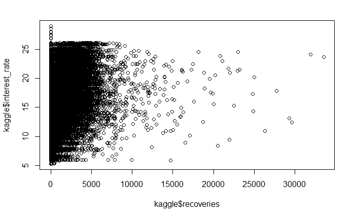

```r
plot(kaggle$interest_rate~kaggle$recoveries)
```

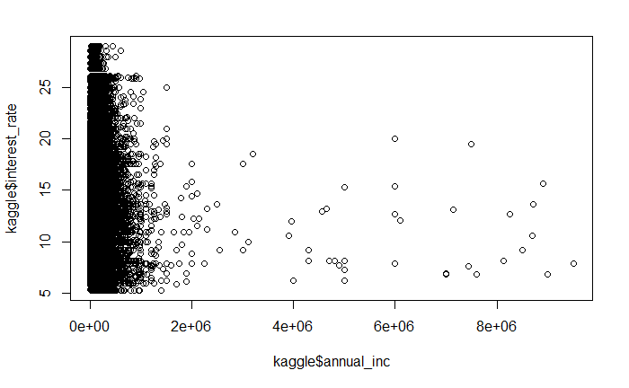

```r
plot(kaggle$interest_rate~kaggle$annual_inc)
```

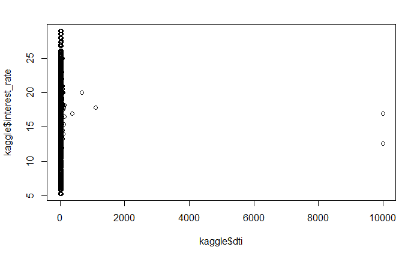

```r
plot(kaggle$interest_rate~kaggle$dti)
```

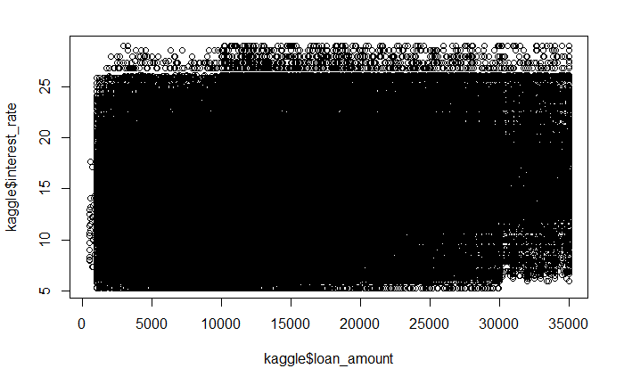

```r
plot(kaggle$interest_rate~kaggle$loan_amount)
```

The graphs are a bit difficult to read, more than likely due to the sheer amount of observations that are being presented in this project. All in all it seems as if all of the assumptions may not have been met, including homoscedascity of the residuals. We can check to see if we have any outliers as well.

```r
mod <- lm(interest_rate~recoveries+annual_inc+dti+loan_amount)
summary(mod)
```

```
Call:
lm(formula = interest_rate ~ recoveries + annual_inc + dti +
    loan_amount)

Residuals:
     Min       1Q   Median       3Q      Max
-165.465   -3.196   -0.202    2.768   79.273

Coefficients:
              Estimate Std. Error t value Pr(>|t|)
(Intercept)  1.217e+01  1.074e-02 1133.35   <2e-16 ***
recoveries   1.012e-03  1.109e-05   91.24   <2e-16 ***
annual_inc  -8.631e-06  7.467e-08 -115.59   <2e-16 ***
dti          1.656e-02  2.650e-04   62.46   <2e-16 ***
loan_amount  9.306e-05  5.722e-07  162.65   <2e-16 ***
---
Signif. codes:  0 ‘***’ 0.001 ‘**’ 0.01 ‘*’ 0.05 ‘.’ 0.1 ‘ ’ 1

Residual standard error: 4.27 on 887374 degrees of freedom
Multiple R-squared:  0.05056,   Adjusted R-squared:  0.05055
F-statistic: 1.181e+04 on 4 and 887374 DF,  p-value: < 2.2e-16
```

```r
outlierTest(mod)
```

|  | rstudent | unadjusted p-value | Bonferroni p |
| --- | --- | --- | --- |
| 484447 | -48.56794 | 0.0000e+00 | 0.0000e+00 |
| 531887 | -49.43730 | 0.0000e+00 | 0.0000e+00 |
| 684001 | 18.79579 | 8.4703e-79 | 7.5164e-73 |
| 866974 | 17.98417 | 2.6704e-72 | 2.3696e-66 |
| 697245 | 17.92491 | 7.7617e-72 | 6.8875e-66 |
| 490863 | 17.12112 | 1.0581e-65 | 9.3892e-60 |
| 506741 | 16.92692 | 2.9161e-64 | 2.5877e-58 |
| 325186 | 16.69836 | 1.3772e-62 | 1.2221e-56 |
| 514273 | 16.39899 | 1.9849e-60 | 1.7614e-54 |
| 552198 | 16.31887 | 7.3939e-60 | 6.5612e-54 |

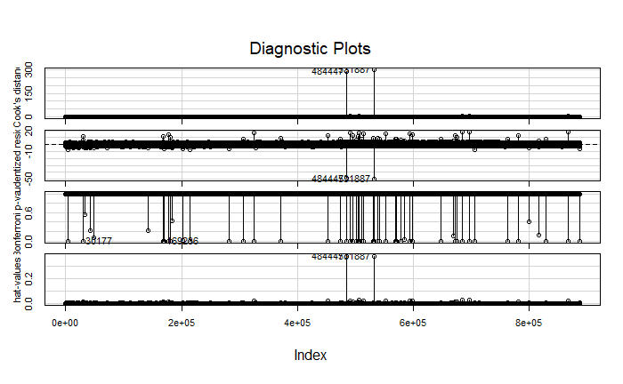

```r
infIndexPlot(mod)
```

First we will look at the output of the linear model we just created. All of our variable seem to show levels of significance if we are to determine them using a p-value of 0.5. The recoveies variable states that with an additional unit increase of recoveries, an increase of the interest rate would occur by about .00101. A unit increase of annual income would result in a decrease of the interest rate by .000008631. A unit increase of dti by 1 unit would increase interest rate by .01656. A unit increase in the loan amount would increase interest rate by .00009306. These seem reasonable, but we now that there is a likelihood that the initial model we created isn’t even the correct model needed to be used. As we can see the variables we have thus far only give us an adusted R-Squared of .05, a very small value to explain the variance of our datapoints.

Looking at the outlier tests, several outliers seem to appear at observations 484447 and observations 531887. Several other observations may need to be checked out too for their possible influence on the dataset as a whole. Let’s observe these observations points and see how they compare with the rest of the data.

```r
summary(kaggle)
```

```
       id                year        issue_d             final_d        emp_length_int   home_ownership
 Min.   :   54734   Min.   :2007   Length:887379      Min.   :1012008   Min.   : 0.500   Length:887379
 1st Qu.: 9206643   1st Qu.:2013   Class :character   1st Qu.:1012016   1st Qu.: 3.000   Class :character
 Median :34433267   Median :2014   Mode  :character   Median :1012016   Median : 6.050   Mode  :character
 Mean   :32465133   Mean   :2014                      Mean   :1047089   Mean   : 6.051
 3rd Qu.:54908135   3rd Qu.:2015                      3rd Qu.:1092015   3rd Qu.:10.000
 Max.   :68617057   Max.   :2015                      Max.   :1122015   Max.   :10.000
 home_ownership_cat income_category      annual_inc        income_cat     loan_amount        term              term_cat
 Min.   :1.000      Length:887379      Min.   :      0   Min.   :1.000   Min.   :  500   Length:887379      Min.   :1.0
 1st Qu.:1.000      Class :character   1st Qu.:  45000   1st Qu.:1.000   1st Qu.: 8000   Class :character   1st Qu.:1.0
 Median :3.000      Mode  :character   Median :  65000   Median :1.000   Median :13000   Mode  :character   Median :1.0
 Mean   :2.099                         Mean   :  75028   Mean   :1.197   Mean   :14755                      Mean   :1.3
 3rd Qu.:3.000                         3rd Qu.:  90000   3rd Qu.:1.000   3rd Qu.:20000                      3rd Qu.:2.0
 Max.   :6.000                         Max.   :9500000   Max.   :3.000   Max.   :35000                      Max.   :2.0
 application_type   application_type_cat   purpose           purpose_cat     interest_payments  interest_payment_cat
 Length:887379      Min.   :1.000        Length:887379      Min.   : 1.000   Length:887379      Min.   :1.000
 Class :character   1st Qu.:1.000        Class :character   1st Qu.: 3.000   Class :character   1st Qu.:1.000
 Mode  :character   Median :1.000        Mode  :character   Median : 6.000   Mode  :character   Median :1.000
                    Mean   :1.001                           Mean   : 4.875                      Mean   :1.476
                    3rd Qu.:1.000                           3rd Qu.: 6.000                      3rd Qu.:2.000
                    Max.   :2.000                           Max.   :14.000                      Max.   :2.000
 loan_condition     loan_condition_cat interest_rate      grade             grade_cat          dti           total_pymnt
 Length:887379      Min.   :0.00000    Min.   : 5.32   Length:887379      Min.   :1.000   Min.   :   0.00   Min.   :    0
 Class :character   1st Qu.:0.00000    1st Qu.: 9.99   Class :character   1st Qu.:2.000   1st Qu.:  11.91   1st Qu.: 1915
 Mode  :character   Median :0.00000    Median :12.99   Mode  :character   Median :3.000   Median :  17.65   Median : 4895
                    Mean   :0.07599    Mean   :13.25                      Mean   :2.798   Mean   :  18.16   Mean   : 7559
                    3rd Qu.:0.00000    3rd Qu.:16.20                      3rd Qu.:4.000   3rd Qu.:  23.95   3rd Qu.:10617
                    Max.   :1.00000    Max.   :28.99                      Max.   :7.000   Max.   :9999.00   Max.   :57778
 total_rec_prncp   recoveries        installment         region
 Min.   :    0   Min.   :    0.00   Min.   :  15.67   Length:887379
 1st Qu.: 1201   1st Qu.:    0.00   1st Qu.: 260.70   Class :character
 Median : 3215   Median :    0.00   Median : 382.55   Mode  :character
 Mean   : 5758   Mean   :   45.92   Mean   : 436.72
 3rd Qu.: 8000   3rd Qu.:    0.00   3rd Qu.: 572.60
 Max.   :35000   Max.   :33520.27   Max.   :1445.46
```

```r
kaggle[484447,]
```

|  | id | year | issue_d | final_d | emp_length_int | home_ownership | home_ownership_cat | income_category | annual_inc | income_cat | loan_amount | term | term_cat | application_type | application_type_cat | purpose | purpose_cat | interest_payments | interest_payment_cat | loan_condition | loan_condition_cat | interest_rate | grade | grade_cat | dti | total_pymnt | total_rec_prncp | recoveries | installment | … |
| --- | --- | --- | --- | --- | --- | --- | --- | --- | --- | --- | --- | --- | --- | --- | --- | --- | --- | --- | --- | --- | --- | --- | --- | --- | --- | --- | --- | --- | --- | --- |
| 484447 | 66415476 | 2015 | 1/12/2015 | 1012016 | 6.05 | MORTGAGE | 3 | Low | 0 | 1 | 20000 | 36 months | 1 | JOINT | 2 | debt_consolidation | 6 | High | 2 | Good Loan | 0 | 16.99 | D | 4 | 9999 | 694.08 | 429.79 | 0 | 712.96 | … |

```r
kaggle[531887,]
```

|  | id | year | issue_d | final_d | emp_length_int | home_ownership | home_ownership_cat | income_category | annual_inc | income_cat | loan_amount | term | term_cat | application_type | application_type_cat | purpose | purpose_cat | interest_payments | interest_payment_cat | loan_condition | loan_condition_cat | interest_rate | grade | grade_cat | dti | total_pymnt | total_rec_prncp | recoveries | installment | … |
| --- | --- | --- | --- | --- | --- | --- | --- | --- | --- | --- | --- | --- | --- | --- | --- | --- | --- | --- | --- | --- | --- | --- | --- | --- | --- | --- | --- | --- | --- | --- |
| 531887 | 65199509 | 2015 | 1/11/2015 | 1012016 | 6.05 | MORTGAGE | 3 | Low | 0 | 1 | 3700 | 36 months | 1 | JOINT | 2 | credit_card | 1 | Low | 1 | Good Loan | 0 | 12.59 | C | 3 | 9999 | 242.7 | 171.13 | 0 | 123.94 | … |

Both of these obervations have dti’s of 9999 which is impossible since dti, is determined as a percentage. It is safe to say that these observations can be removed due to the fact that they have a value on a variable that is impossible to get. What I want to do first is use create a model with those outliers first, then compare it with a model without those outliers.

```r
modmod <- lm(interest_rate~recoveries+annual_inc+dti+loan_amount, kaggle[-c(484447, 531887),])
summary(modmod)
```

```
Call:
lm(formula = interest_rate ~ recoveries + annual_inc + dti +
    loan_amount, data = kaggle[-c(484447, 531887), ])

Residuals:
    Min      1Q  Median      3Q     Max
-71.228  -3.168  -0.217   2.726  66.988

Coefficients:
              Estimate Std. Error t value Pr(>|t|)
(Intercept)  1.117e+01  1.386e-02   805.8   <2e-16 ***
recoveries   1.017e-03  1.102e-05    92.3   <2e-16 ***
annual_inc  -7.131e-06  7.531e-08   -94.7   <2e-16 ***
dti          7.081e-02  5.457e-04   129.8   <2e-16 ***
loan_amount  8.687e-05  5.707e-07   152.2   <2e-16 ***
---
Signif. codes:  0 ‘***’ 0.001 ‘**’ 0.01 ‘*’ 0.05 ‘.’ 0.1 ‘ ’ 1

Residual standard error: 4.239 on 887372 degrees of freedom
Multiple R-squared:  0.06414,   Adjusted R-squared:  0.06414
F-statistic: 1.52e+04 on 4 and 887372 DF,  p-value: < 2.2e-16
```

All the coefficient values have changed slightly with the exception of the dti coefficient which went from .0165 to .0708. Now to check if our assumptions have been met regarding this model.

```r
ncvTest(modmod)
```

```
Non-constant Variance Score Test
Variance formula: ~ fitted.values
Chisquare = 4782.999, Df = 1, p = < 2.22e-16
```

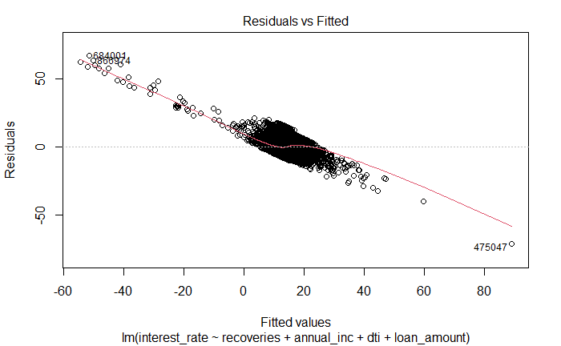

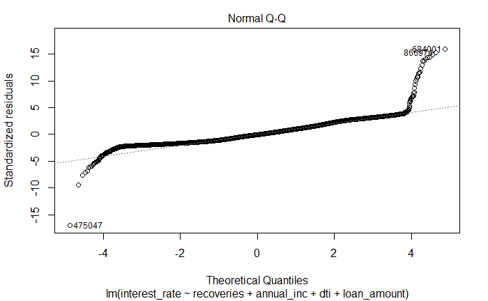

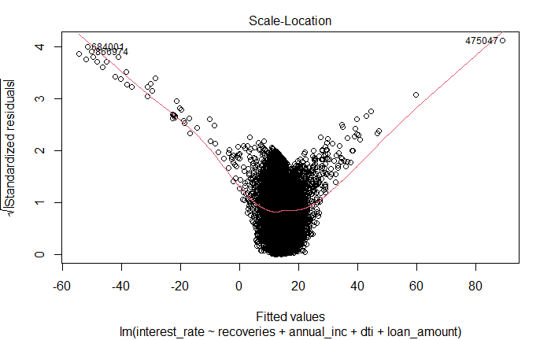

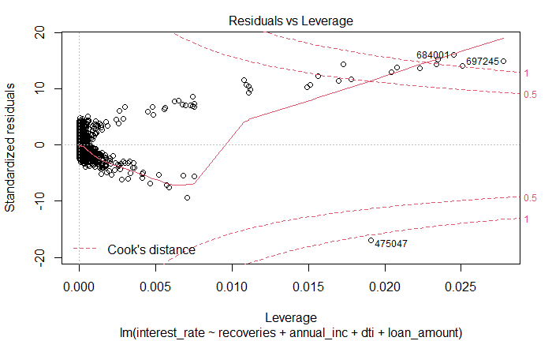

```r
plot(modmod)
```

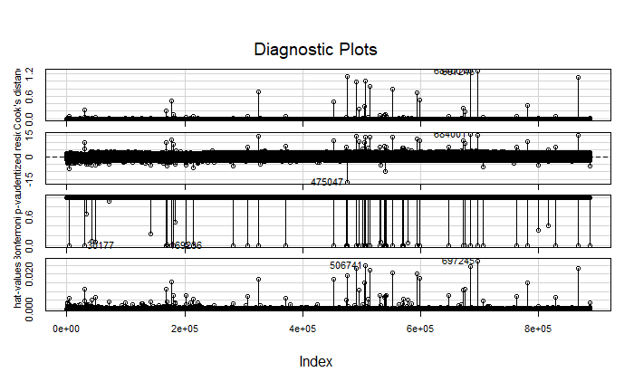

```r
infIndexPlot(modmod)
```

```r
outlierTest(modmod)
```

|  | rstudent | unadjusted p-value | Bonferroni p |
| --- | --- | --- | --- |
| 475047 | -16.96845 | 1.4393e-64 | 1.2772e-58 |
| 684001 | 16.00214 | 1.2577e-57 | 1.1160e-51 |
| 866974 | 15.25107 | 1.6446e-52 | 1.4593e-46 |
| 697245 | 14.92494 | 2.3007e-50 | 2.0416e-44 |
| 325186 | 14.40328 | 4.9953e-47 | 4.4327e-41 |
| 490863 | 14.39211 | 5.8715e-47 | 5.2102e-41 |
| 506741 | 14.08371 | 4.8371e-45 | 4.2923e-39 |
| 552198 | 13.77106 | 3.8448e-43 | 3.4118e-37 |
| 514273 | 13.73401 | 6.4162e-43 | 5.6936e-37 |
| 594271 | 12.98132 | 1.5744e-38 | 1.3971e-32 |

As suspected, our assumptions were not met. It doesn’t seem as if we accounted for homoscedacity and we have 3 major outliers we need to observe. We also have a normality assumption that has not been met yet. Once again, I am going to look at these outliers and compare them to the rest of the data.

```r
kaggle[475047,]
```

|  | id | year | issue_d | final_d | emp_length_int | home_ownership | home_ownership_cat | income_category | annual_inc | income_cat | loan_amount | term | term_cat | application_type | application_type_cat | purpose | purpose_cat | interest_payments | interest_payment_cat | loan_condition | loan_condition_cat | interest_rate | grade | grade_cat | dti | total_pymnt | total_rec_prncp | recoveries | installment | … |
| --- | --- | --- | --- | --- | --- | --- | --- | --- | --- | --- | --- | --- | --- | --- | --- | --- | --- | --- | --- | --- | --- | --- | --- | --- | --- | --- | --- | --- | --- | --- |
| 475047 | 67405134 | 2015 | 1/12/2015 | 1012016 | 6.05 | MORTGAGE | 3 | Low | 1770 | 1 | 6550 | 36 months | 1 | JOINT | 2 | credit_card | 1 | High | 2 | Good Loan | 0 | 17.86 | D | 4 | 1092.52 | 0 | 0 | 0 | 236.34 | … |

```r
kaggle[684001,]
```

|  | id | year | issue_d | final_d | emp_length_int | home_ownership | home_ownership_cat | income_category | annual_inc | income_cat | loan_amount | term | term_cat | application_type | application_type_cat | purpose | purpose_cat | interest_payments | interest_payment_cat | loan_condition | loan_condition_cat | interest_rate | grade | grade_cat | dti | total_pymnt | total_rec_prncp | recoveries | installment | … |
| --- | --- | --- | --- | --- | --- | --- | --- | --- | --- | --- | --- | --- | --- | --- | --- | --- | --- | --- | --- | --- | --- | --- | --- | --- | --- | --- | --- | --- | --- | --- |
| 684001 | 55140826 | 2015 | 1/7/2015 | 1012016 | 10 | RENT | 1 | High | 8900060 | 3 | 10550 | 36 months | 1 | INDIVIDUAL | 1 | debt_consolidation | 6 | High | 2 | Bad Loan | 1 | 15.61 | D | 4 | 0.09 | 1826.1 | 1188.74 | 0 | 368.88 | … |

```r
kaggle[697245,]
```

|  | id | year | issue_d | final_d | emp_length_int | home_ownership | home_ownership_cat | income_category | annual_inc | income_cat | loan_amount | term | term_cat | application_type | application_type_cat | purpose | purpose_cat | interest_payments | interest_payment_cat | loan_condition | loan_condition_cat | interest_rate | grade | grade_cat | dti | total_pymnt | total_rec_prncp | recoveries | installment | … |
| --- | --- | --- | --- | --- | --- | --- | --- | --- | --- | --- | --- | --- | --- | --- | --- | --- | --- | --- | --- | --- | --- | --- | --- | --- | --- | --- | --- | --- | --- | --- |
| 697245 | 54067210 | 2015 | 1/7/2015 | 1012016 | 10 | MORTGAGE | 3 | High | 9500000 | 3 | 24000 | 60 months | 2 | INDIVIDUAL | 1 | credit_card | 1 | Low | 1 | Good Loan | 0 | 7.89 | A | 1 | 0.12 | 2901.76 | 1998.07 | 0 | 485.38 | … |

```r
kaggle[866974,]
```

|  | id | year | issue_d | final_d | emp_length_int | home_ownership | home_ownership_cat | income_category | annual_inc | income_cat | loan_amount | term | term_cat | application_type | application_type_cat | purpose | purpose_cat | interest_payments | interest_payment_cat | loan_condition | loan_condition_cat | interest_rate | grade | grade_cat | dti | total_pymnt | total_rec_prncp | recoveries | installment | … |
| --- | --- | --- | --- | --- | --- | --- | --- | --- | --- | --- | --- | --- | --- | --- | --- | --- | --- | --- | --- | --- | --- | --- | --- | --- | --- | --- | --- | --- | --- | --- |
| 866974 | 39429853 | 2015 | 1/1/2015 | 1062015 | 10 | MORTGAGE | 3 | High | 8706582 | 3 | 8000 | 36 months | 1 | INDIVIDUAL | 1 | credit_card | 1 | High | 2 | Bad Loan | 1 | 13.66 | C | 3 | 0.11 | 1345.37 | 926.06 | 0 | 272.11 | … |

Next I remove observation 475047 and use powertransformations to see if we can finally improve our assumptions.

```r
kaggle2 <- kaggle[-c(484447, 531887, 475047),]
mod3 <- lm(interest_rate~recoveries+annual_inc+dti+loan_amount, kaggle2)
summary(mod3)
```

```
Call:
lm(formula = interest_rate ~ recoveries + annual_inc + dti +
    loan_amount, data = kaggle2)

Residuals:
    Min      1Q  Median      3Q     Max
-40.678  -3.167  -0.217   2.724  66.704

Coefficients:
              Estimate Std. Error t value Pr(>|t|)
(Intercept)  1.115e+01  1.393e-02  800.14   <2e-16 ***
recoveries   1.017e-03  1.101e-05   92.32   <2e-16 ***
annual_inc  -7.097e-06  7.532e-08  -94.22   <2e-16 ***
dti          7.210e-02  5.509e-04  130.88   <2e-16 ***
loan_amount  8.672e-05  5.707e-07  151.95   <2e-16 ***
---
Signif. codes:  0 ‘***’ 0.001 ‘**’ 0.01 ‘*’ 0.05 ‘.’ 0.1 ‘ ’ 1

Residual standard error: 4.238 on 887371 degrees of freedom
Multiple R-squared:  0.06444,   Adjusted R-squared:  0.06444
F-statistic: 1.528e+04 on 4 and 887371 DF,  p-value: < 2.2e-16
```

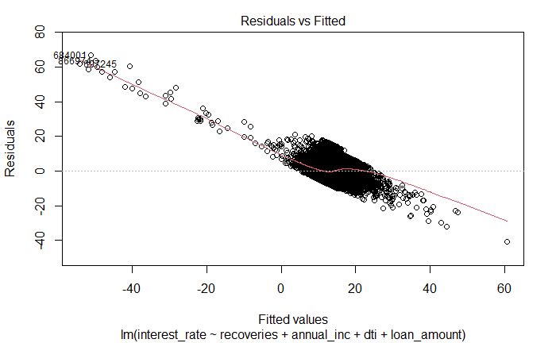

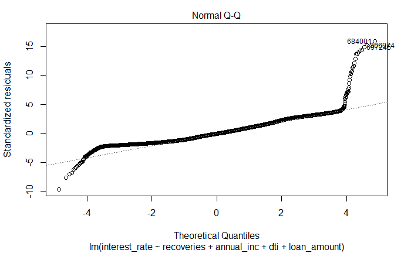

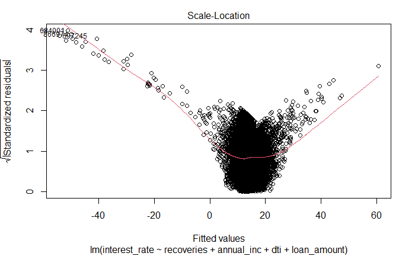

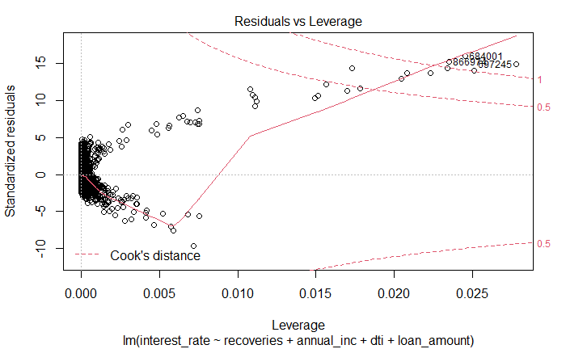

```r
plot(mod3)
```

```r
ncvTest(mod3)
```

```
Non-constant Variance Score Test
Variance formula: ~ fitted.values
Chisquare = 6686.252, Df = 1, p = < 2.22e-16
```

```r
outlierTest(mod3)
```

|  | rstudent | unadjusted p-value | Bonferroni p |
| --- | --- | --- | --- |
| 684001 | 15.93703 | 3.5713e-57 | 3.1691e-51 |
| 866974 | 15.18736 | 4.3534e-52 | 3.8631e-46 |
| 697245 | 14.85504 | 6.5427e-50 | 5.8058e-44 |
| 325186 | 14.34981 | 1.0812e-46 | 9.5947e-41 |
| 490863 | 14.32851 | 1.4695e-46 | 1.3040e-40 |
| 506741 | 14.01744 | 1.2327e-44 | 1.0939e-38 |
| 552198 | 13.71174 | 8.7232e-43 | 7.7408e-37 |
| 514273 | 13.67191 | 1.5091e-42 | 1.3392e-36 |
| 594271 | 12.92194 | 3.4118e-38 | 3.0275e-32 |
| 177183 | 12.21111 | 2.7290e-34 | 2.4217e-28 |

Once again, our assumptions have not been met. Now it is time to transform our variables out to hopefully fix these assumptions.

```r
summary(powerTransform(cbind(recoveries, annual_inc, dti, loan_amount)~ 1, kaggle2, family = "bcnPower"))
```

```
bcnPower transformation to Multinormality

Estimated power, lambda
            Est Power Rounded Pwr Wald Lwr Bnd Wald Upr Bnd
recoveries    -3.0000      -3.000      -3.0062      -2.9938
annual_inc    -0.3003      -0.300      -0.3034      -0.2972
dti           -3.0000      -3.000      -3.0317      -2.9683
loan_amount    0.4544       0.454       0.4517       0.4571

Estimated location, gamma
             Est gamma Std Err. Wald Lower Bound Wald Upper Bound
recoveries      0.1000       NA               NA               NA
annual_inc  25628.4213       NA               NA               NA
dti           246.9596       NA               NA               NA
loan_amount     0.1000       NA               NA               NA

Likelihood ratio tests about transformation parameters
```

|  | LRT | df | pval |
| --- | --- | --- | --- |
| LR test, lambda = (0 0 0 0) | 4741708 | 4 | 0 |
| LR test, lambda = (1 1 1 1) | 20843910 | 4 | 0 |

Looking at the proposed power transformations, it looks as if we are getting figures, however these figures may prove to cause difficulty in interpretation. Since the sole purpose of this project is for inferential purposes, we may havve to do some additional rounding of the figures compared to the original ones given. For this case, I am going to use a log transformation for the variable “annual_inc” and the variable “loan_amount”.

```r
mod4 <- lm(interest_rate~recoveries+log(annual_inc)+dti+log(loan_amount), kaggle2)
summary(mod4)
```

```
Call:
lm(formula = interest_rate ~ recoveries + log(annual_inc) + dti +
    log(loan_amount), data = kaggle2)

Residuals:
    Min      1Q  Median      3Q     Max
-38.908  -3.153  -0.256   2.720  19.296

Coefficients:
                   Estimate Std. Error t value Pr(>|t|)
(Intercept)       1.697e+01  1.004e-01  168.97   <2e-16 ***
recoveries        1.048e-03  1.099e-05   95.36   <2e-16 ***
log(annual_inc)  -1.427e+00  1.010e-02 -141.28   <2e-16 ***
dti               6.117e-02  5.608e-04  109.08   <2e-16 ***
log(loan_amount)  1.161e+00  7.835e-03  148.16   <2e-16 ***
---
Signif. codes:  0 ‘***’ 0.001 ‘**’ 0.01 ‘*’ 0.05 ‘.’ 0.1 ‘ ’ 1

Residual standard error: 4.232 on 887371 degrees of freedom
Multiple R-squared:  0.06732,   Adjusted R-squared:  0.06732
F-statistic: 1.601e+04 on 4 and 887371 DF,  p-value: < 2.2e-16
```

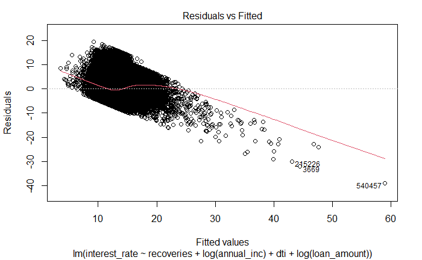

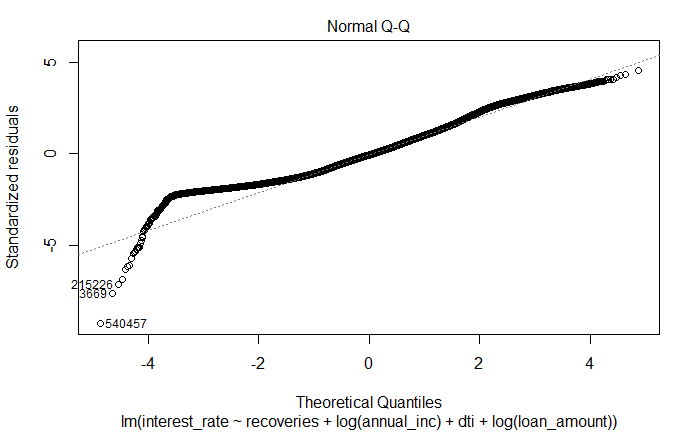

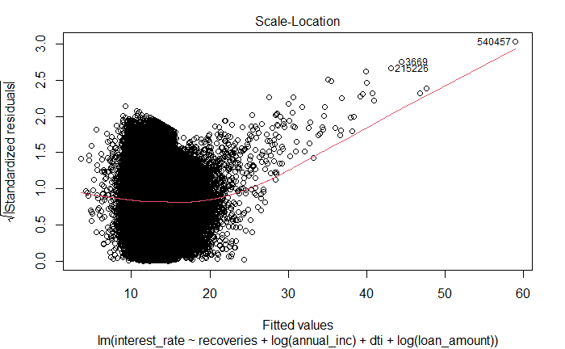

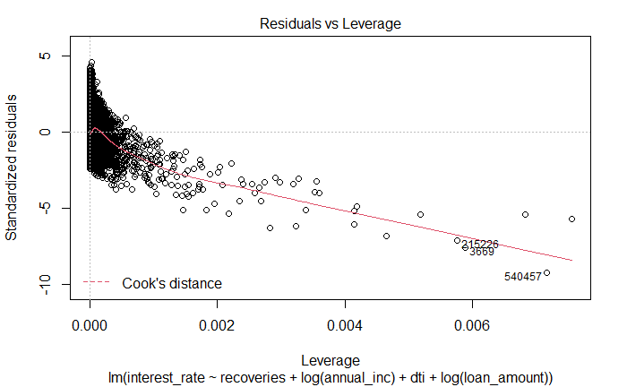

```r
plot(mod4)
```

```r
ncvTest(mod4)
```

```
Non-constant Variance Score Test
Variance formula: ~ fitted.values
Chisquare = 593.9579, Df = 1, p = < 2.22e-16
```

The assumptions are still not met, it still looks as if all of them are being violated. For curiosity purposes,I am going to use the actual recommended lambda values given to me through the powerTransform recommendations to see if they would fix our assumption violations.However, doing so, we would lose a tremendous amount of interpretability and instead would have to resort to predictability which is not the goal of this project.The amount of 0’s in some of the variables, especially the recoveries variable can prove to be very troublesome and may not be feesible for this type of problem. At this moment in time, a linear regression model may not be suitable, especailly for variables like recoveries and dti which contain a good amount of zero values.

```r
kaggleset <- subset(kaggle2, dti!= 0)
length(which(kaggleset$dti == 0))
```

```
[1] 0
```

```r
length(which(kaggleset$annual_inc == 0))
```

```
[1] 0
```

```r
modtrans <- lm(interest_rate~recoveries+I(annual_inc^(-0.3))+I(dti^(-3))+I(loan_amount^(.454)), kaggleset)
summary(modtrans)
```

```
Call:
lm(formula = interest_rate ~ recoveries + I(annual_inc^(-0.3)) +
    I(dti^(-3)) + I(loan_amount^(0.454)), data = kaggleset)

Residuals:
    Min      1Q  Median      3Q     Max
-31.656  -3.156  -0.230   2.752  18.728

Coefficients:
                        Estimate Std. Error t value Pr(>|t|)
(Intercept)            2.770e+00  4.612e-02  60.064   <2e-16 ***
recoveries             1.006e-03  1.099e-05  91.516   <2e-16 ***
I(annual_inc^(-0.3))   1.802e+02  9.093e-01 198.169   <2e-16 ***
I(dti^(-3))            5.446e-07  1.325e-06   0.411    0.681
I(loan_amount^(0.454)) 5.151e-02  2.535e-04 203.225   <2e-16 ***
---
Signif. codes:  0 ‘***’ 0.001 ‘**’ 0.01 ‘*’ 0.05 ‘.’ 0.1 ‘ ’ 1

Residual standard error: 4.231 on 886920 degrees of freedom
Multiple R-squared:  0.06738,   Adjusted R-squared:  0.06738
F-statistic: 1.602e+04 on 4 and 886920 DF,  p-value: < 2.2e-16
```

In this case, it is very difficult to transform the recoveries to one with a log transformation or a negative power transformation due to the recoveries variable having 862699 zeroes out of 887376 observations. It is clear that a simple linear regeression model is not the best model if we were to use this variable. Because the recoveries variable is a variable I believe is inappropiate for this model, I am very inclined to remove it, as recoveries are not much of an indicator on one’s interest rate of the same loan.Looking at the summary output, only the transformed version of DTI seems to be insignificant wherelse all other variables are statistically significant. I can use an ANOVA to determine if I should really remove the recoveries variable.

```r
anova(modtrans)
```

```
Analysis of Variance Table

Response: interest_rate
                           Df   Sum Sq Mean Sq    F value Pr(>F)
recoveries                  1   194367  194367 10855.8548 <2e-16 ***
I(annual_inc^(-0.3))        1   213491  213491 11923.9846 <2e-16 ***
I(dti^(-3))                 1        2       2     0.0869 0.7682
I(loan_amount^(0.454))      1   739460  739460 41300.5505 <2e-16 ***
Residuals              886920 15879734      18
---
Signif. codes:  0 ‘***’ 0.001 ‘**’ 0.01 ‘*’ 0.05 ‘.’ 0.1 ‘ ’ 1
```

Nope, the ANOvA believes that using the recoveries variable is better than just using the mean function without it. Once again, the transformed dti variable is a feature that is recommended to be removed. At this point it is probably better to add more variables to see if they can explain the relationship a bit better. Adding higher order terms for our predictors, such as interactions and polynomials, is probably going to be appropriate moving forward.

Next, we will showcase all of the variables and how they affect the influence on the interest rate.

```r
summary(kaggle)
```

```
       id                year        issue_d             final_d        emp_length_int   home_ownership
 Min.   :   54734   Min.   :2007   Length:887379      Min.   :1012008   Min.   : 0.500   Length:887379
 1st Qu.: 9206643   1st Qu.:2013   Class :character   1st Qu.:1012016   1st Qu.: 3.000   Class :character
 Median :34433267   Median :2014   Mode  :character   Median :1012016   Median : 6.050   Mode  :character
 Mean   :32465133   Mean   :2014                      Mean   :1047089   Mean   : 6.051
 3rd Qu.:54908135   3rd Qu.:2015                      3rd Qu.:1092015   3rd Qu.:10.000
 Max.   :68617057   Max.   :2015                      Max.   :1122015   Max.   :10.000
 home_ownership_cat income_category      annual_inc        income_cat     loan_amount        term              term_cat
 Min.   :1.000      Length:887379      Min.   :      0   Min.   :1.000   Min.   :  500   Length:887379      Min.   :1.0
 1st Qu.:1.000      Class :character   1st Qu.:  45000   1st Qu.:1.000   1st Qu.: 8000   Class :character   1st Qu.:1.0
 Median :3.000      Mode  :character   Median :  65000   Median :1.000   Median :13000   Mode  :character   Median :1.0
 Mean   :2.099                         Mean   :  75028   Mean   :1.197   Mean   :14755                      Mean   :1.3
 3rd Qu.:3.000                         3rd Qu.:  90000   3rd Qu.:1.000   3rd Qu.:20000                      3rd Qu.:2.0
 Max.   :6.000                         Max.   :9500000   Max.   :3.000   Max.   :35000                      Max.   :2.0
 application_type   application_type_cat   purpose           purpose_cat     interest_payments  interest_payment_cat
 Length:887379      Min.   :1.000        Length:887379      Min.   : 1.000   Length:887379      Min.   :1.000
 Class :character   1st Qu.:1.000        Class :character   1st Qu.: 3.000   Class :character   1st Qu.:1.000
 Mode  :character   Median :1.000        Mode  :character   Median : 6.000   Mode  :character   Median :1.000
                    Mean   :1.001                           Mean   : 4.875                      Mean   :1.476
                    3rd Qu.:1.000                           3rd Qu.: 6.000                      3rd Qu.:2.000
                    Max.   :2.000                           Max.   :14.000                      Max.   :2.000
 loan_condition     loan_condition_cat interest_rate      grade             grade_cat          dti           total_pymnt
 Length:887379      Min.   :0.00000    Min.   : 5.32   Length:887379      Min.   :1.000   Min.   :   0.00   Min.   :    0
 Class :character   1st Qu.:0.00000    1st Qu.: 9.99   Class :character   1st Qu.:2.000   1st Qu.:  11.91   1st Qu.: 1915
 Mode  :character   Median :0.00000    Median :12.99   Mode  :character   Median :3.000   Median :  17.65   Median : 4895
                    Mean   :0.07599    Mean   :13.25                      Mean   :2.798   Mean   :  18.16   Mean   : 7559
                    3rd Qu.:0.00000    3rd Qu.:16.20                      3rd Qu.:4.000   3rd Qu.:  23.95   3rd Qu.:10617
                    Max.   :1.00000    Max.   :28.99                      Max.   :7.000   Max.   :9999.00   Max.   :57778
 total_rec_prncp   recoveries        installment         region
 Min.   :    0   Min.   :    0.00   Min.   :  15.67   Length:887379
 1st Qu.: 1201   1st Qu.:    0.00   1st Qu.: 260.70   Class :character
 Median : 3215   Median :    0.00   Median : 382.55   Mode  :character
 Mean   : 5758   Mean   :   45.92   Mean   : 436.72
 3rd Qu.: 8000   3rd Qu.:    0.00   3rd Qu.: 572.60
 Max.   :35000   Max.   :33520.27   Max.   :1445.46
```

```r
str(kaggle)
```

```
'data.frame':   887379 obs. of  30 variables:
 $ id                  : int  1077501 1077430 1077175 1076863 1075358 1075269 1069639 1072053 1071795 1071570 ...
 $ year                : int  2011 2011 2011 2011 2011 2011 2011 2011 2011 2011 ...
 $ issue_d             : chr  "1/12/2011" "1/12/2011" "1/12/2011" "1/12/2011" ...
 $ final_d             : int  1012015 1042013 1062014 1012015 1012016 1012015 1012016 1012015 1042012 1112012 ...
 $ emp_length_int      : num  10 0.5 10 10 1 3 8 9 4 0.5 ...
 $ home_ownership      : chr  "RENT" "RENT" "RENT" "RENT" ...
 $ home_ownership_cat  : int  1 1 1 1 1 1 1 1 2 1 ...
 $ income_category     : chr  "Low" "Low" "Low" "Low" ...
 $ annual_inc          : int  24000 30000 12252 49200 80000 36000 47004 48000 40000 15000 ...
 $ income_cat          : int  1 1 1 1 1 1 1 1 1 1 ...
 $ loan_amount         : int  5000 2500 2400 10000 3000 5000 7000 3000 5600 5375 ...
 $ term                : chr  " 36 months" " 60 months" " 36 months" " 36 months" ...
 $ term_cat            : int  1 2 1 1 2 1 2 1 2 2 ...
 $ application_type    : chr  "INDIVIDUAL" "INDIVIDUAL" "INDIVIDUAL" "INDIVIDUAL" ...
```

[output cut: 16 more lines]

```r
fullmod <- lm(interest_rate~.,kaggle[,-1])
summary(fullmod)
```

```
Call:
lm(formula = interest_rate ~ ., data = kaggle[, -1])

Residuals:
     Min       1Q   Median       3Q      Max
-16.2229  -0.6450   0.0450   0.7156   4.9600

Coefficients: (9 not defined because of singularities)
                            Estimate Std. Error  t value Pr(>|t|)
(Intercept)               -5.706e+02  1.603e+01  -35.585  < 2e-16 ***
year                       2.873e-01  7.953e-03   36.124  < 2e-16 ***
issue_d1/1/2009            1.953e+00  7.559e-02   25.843  < 2e-16 ***
issue_d1/1/2010            1.674e+00  5.450e-02   30.716  < 2e-16 ***
issue_d1/1/2011            3.944e-01  4.102e-02    9.613  < 2e-16 ***
issue_d1/1/2012            1.555e+00  3.060e-02   50.815  < 2e-16 ***
issue_d1/1/2013            2.184e+00  2.028e-02  107.688  < 2e-16 ***
issue_d1/1/2014            1.541e+00  1.236e-02  124.721  < 2e-16 ***
issue_d1/1/2015            2.751e-01  7.789e-03   35.320  < 2e-16 ***
issue_d1/10/2007          -6.148e-01  1.134e-01   -5.420 5.97e-08 ***
issue_d1/10/2008           1.448e+00  1.034e-01   14.007  < 2e-16 ***
issue_d1/10/2009           2.121e+00  6.156e-02   34.449  < 2e-16 ***
issue_d1/10/2010           8.586e-01  4.818e-02   17.819  < 2e-16 ***
issue_d1/10/2011           1.700e+00  3.808e-02   44.634  < 2e-16 ***
issue_d1/10/2012           2.331e+00  2.699e-02   86.389  < 2e-16 ***
issue_d1/10/2013           2.144e+00  1.840e-02  116.509  < 2e-16 ***
issue_d1/10/2014           7.365e-01  1.060e-02   69.511  < 2e-16 ***
issue_d1/10/2015          -1.432e-02  7.190e-03   -1.992 0.046384 *
issue_d1/11/2007          -3.644e-01  1.110e-01   -3.284 0.001024 **
issue_d1/11/2008           1.625e+00  8.670e-02   18.740  < 2e-16 ***
issue_d1/11/2009           2.086e+00  6.045e-02   34.514  < 2e-16 ***
issue_d1/11/2010           6.209e-01  4.823e-02   12.874  < 2e-16 ***
issue_d1/11/2011           1.746e+00  3.778e-02   46.225  < 2e-16 ***
issue_d1/11/2012           2.336e+00  2.695e-02   86.682  < 2e-16 ***
issue_d1/11/2013           2.082e+00  1.833e-02  113.607  < 2e-16 ***
issue_d1/11/2014           5.901e-01  1.118e-02   52.802  < 2e-16 ***
issue_d1/11/2015           1.014e-03  7.584e-03    0.134 0.893623
issue_d1/12/2007          -2.584e-01  9.698e-02   -2.664 0.007713 **
issue_d1/12/2008           2.330e+00  8.210e-02   28.385  < 2e-16 ***
issue_d1/12/2009           2.253e+00  6.052e-02   37.237  < 2e-16 ***
issue_d1/12/2010           4.970e-01  4.756e-02   10.449  < 2e-16 ***
```

[output cut: 115 more lines]

```
dti                        8.773e-04  6.072e-05   14.448  < 2e-16 ***
total_pymnt                6.059e-05  8.185e-07   74.026  < 2e-16 ***
total_rec_prncp           -6.993e-05  8.623e-07  -81.093  < 2e-16 ***
recoveries                -6.917e-05  2.830e-06  -24.444  < 2e-16 ***
installment                5.065e-03  2.870e-05  176.465  < 2e-16 ***
regionleinster             6.299e-03  3.221e-03    1.956 0.050482 .
regionmunster              8.417e-03  3.871e-03    2.175 0.029666 *
regionNorthern-Irl        -1.054e-02  3.285e-03   -3.209 0.001334 **
regionulster               9.339e-04  3.285e-03    0.284 0.776198
---
Signif. codes:  0 ‘***’ 0.001 ‘**’ 0.01 ‘*’ 0.05 ‘.’ 0.1 ‘ ’ 1

Residual standard error: 0.965 on 887233 degrees of freedom
Multiple R-squared:  0.9515,    Adjusted R-squared:  0.9515
F-statistic: 1.201e+05 on 145 and 887233 DF,  p-value: < 2.2e-16
```

This is the result of our linear regression model without doing any data wrangling. As you can see, some of our estimated parameters have “NA” values next to them. Usually this indicates that there is overparameterization. Now it is time to transform some of these variables to the appropriate data type, factors.

```r
str(kaggle)
```

```
'data.frame':   887379 obs. of  30 variables:
 $ id                  : int  1077501 1077430 1077175 1076863 1075358 1075269 1069639 1072053 1071795 1071570 ...
 $ year                : int  2011 2011 2011 2011 2011 2011 2011 2011 2011 2011 ...
 $ issue_d             : chr  "1/12/2011" "1/12/2011" "1/12/2011" "1/12/2011" ...
 $ final_d             : int  1012015 1042013 1062014 1012015 1012016 1012015 1012016 1012015 1042012 1112012 ...
 $ emp_length_int      : num  10 0.5 10 10 1 3 8 9 4 0.5 ...
 $ home_ownership      : chr  "RENT" "RENT" "RENT" "RENT" ...
 $ home_ownership_cat  : int  1 1 1 1 1 1 1 1 2 1 ...
 $ income_category     : chr  "Low" "Low" "Low" "Low" ...
 $ annual_inc          : int  24000 30000 12252 49200 80000 36000 47004 48000 40000 15000 ...
 $ income_cat          : int  1 1 1 1 1 1 1 1 1 1 ...
 $ loan_amount         : int  5000 2500 2400 10000 3000 5000 7000 3000 5600 5375 ...
 $ term                : chr  " 36 months" " 60 months" " 36 months" " 36 months" ...
 $ term_cat            : int  1 2 1 1 2 1 2 1 2 2 ...
 $ application_type    : chr  "INDIVIDUAL" "INDIVIDUAL" "INDIVIDUAL" "INDIVIDUAL" ...
```

[output cut: 16 more lines]

```r
kaggle2 <- kaggle
nonfactor <- list(2,3,4,6,7,8,10,12,13,14,15,16,17,18,19,20,21,23,24,30)
for(i in nonfactor){
  kaggle2[ ,i] <- as.factor(kaggle2[ , i])
}
```

```r
str(kaggle2)
```

```
'data.frame':   887379 obs. of  30 variables:
 $ id                  : int  1077501 1077430 1077175 1076863 1075358 1075269 1069639 1072053 1071795 1071570 ...
 $ year                : Factor w/ 9 levels "2007","2008",..: 5 5 5 5 5 5 5 5 5 5 ...
 $ issue_d             : Factor w/ 103 levels "1/1/2008","1/1/2009",..: 31 31 31 31 31 31 31 31 31 31 ...
 $ final_d             : Factor w/ 98 levels "1012008","1012009",..: 8 31 48 8 9 8 9 8 30 86 ...
 $ emp_length_int      : num  10 0.5 10 10 1 3 8 9 4 0.5 ...
 $ home_ownership      : Factor w/ 6 levels "ANY","MORTGAGE",..: 6 6 6 6 6 6 6 6 5 6 ...
 $ home_ownership_cat  : Factor w/ 6 levels "1","2","3","4",..: 1 1 1 1 1 1 1 1 2 1 ...
 $ income_category     : Factor w/ 3 levels "High","Low","Medium": 2 2 2 2 2 2 2 2 2 2 ...
 $ annual_inc          : int  24000 30000 12252 49200 80000 36000 47004 48000 40000 15000 ...
 $ income_cat          : Factor w/ 3 levels "1","2","3": 1 1 1 1 1 1 1 1 1 1 ...
 $ loan_amount         : int  5000 2500 2400 10000 3000 5000 7000 3000 5600 5375 ...
 $ term                : Factor w/ 2 levels " 36 months"," 60 months": 1 2 1 1 2 1 2 1 2 2 ...
 $ term_cat            : Factor w/ 2 levels "1","2": 1 2 1 1 2 1 2 1 2 2 ...
 $ application_type    : Factor w/ 2 levels "INDIVIDUAL","JOINT": 1 1 1 1 1 1 1 1 1 1 ...
```

[output cut: 16 more lines]

```r
fullmod2 <- lm(interest_rate~., kaggle2[,-1])
summary(fullmod2)
```

```
Call:
lm(formula = interest_rate ~ ., data = kaggle2[, -1])

Residuals:
     Min       1Q   Median       3Q      Max
-16.1489  -0.6371   0.0440   0.7097   5.1666

Coefficients: (38 not defined because of singularities)
                            Estimate Std. Error  t value Pr(>|t|)
(Intercept)                5.981e+00  6.401e-01    9.345  < 2e-16 ***
year2008                   1.232e+00  1.458e-01    8.452  < 2e-16 ***
year2009                   3.612e+00  1.422e-01   25.412  < 2e-16 ***
year2010                   2.936e+00  1.389e-01   21.134  < 2e-16 ***
year2011                   3.627e+00  1.379e-01   26.291  < 2e-16 ***
year2012                   4.769e+00  1.370e-01   34.811  < 2e-16 ***
year2013                   4.889e+00  1.368e-01   35.748  < 2e-16 ***
year2014                   4.023e+00  1.369e-01   29.394  < 2e-16 ***
year2015                   3.630e+00  1.367e-01   26.546  < 2e-16 ***
issue_d1/1/2009           -2.528e-01  7.376e-02   -3.428 0.000609 ***
issue_d1/1/2010            4.287e-01  4.734e-02    9.057  < 2e-16 ***
issue_d1/1/2011           -1.181e+00  3.367e-02  -35.069  < 2e-16 ***
issue_d1/1/2012           -8.083e-01  2.279e-02  -35.472  < 2e-16 ***
issue_d1/1/2013            1.451e-01  1.439e-02   10.080  < 2e-16 ***
issue_d1/1/2014            7.490e-01  1.218e-02   61.501  < 2e-16 ***
issue_d1/1/2015            2.412e-01  7.769e-03   31.041  < 2e-16 ***
issue_d1/10/2007           3.179e-01  1.635e-01    1.944 0.051894 .
issue_d1/10/2008           1.364e+00  1.060e-01   12.867  < 2e-16 ***
issue_d1/10/2009          -8.231e-02  5.847e-02   -1.408 0.159205
issue_d1/10/2010          -3.141e-01  3.923e-02   -8.005 1.19e-15 ***
issue_d1/10/2011           1.837e-01  2.978e-02    6.170 6.85e-10 ***
issue_d1/10/2012           3.326e-02  1.747e-02    1.903 0.056985 .
issue_d1/10/2013           1.711e-01  1.169e-02   14.638  < 2e-16 ***
issue_d1/10/2014           4.006e-03  1.054e-02    0.380 0.703770
issue_d1/10/2015          -1.307e-02  7.160e-03   -1.825 0.067938 .
issue_d1/11/2007           6.164e-01  1.637e-01    3.767 0.000166 ***
issue_d1/11/2008           1.533e+00  8.956e-02   17.117  < 2e-16 ***
issue_d1/11/2009          -1.100e-01  5.777e-02   -1.904 0.056859 .
issue_d1/11/2010          -5.470e-01  3.941e-02  -13.878  < 2e-16 ***
issue_d1/11/2011           2.350e-01  2.948e-02    7.973 1.55e-15 ***
issue_d1/11/2012           6.369e-02  1.744e-02    3.652 0.000260 ***
```

[output cut: 161 more lines]

```
final_d1112009            -5.612e-01  3.146e-01   -1.784 0.074440 .
final_d1112010            -5.217e-01  3.009e-01   -1.734 0.082901 .
final_d1112011            -6.082e-01  2.993e-01   -2.032 0.042113 *
final_d1112012            -6.063e-01  2.974e-01   -2.039 0.041495 *
final_d1112013            -6.484e-01  2.968e-01   -2.185 0.028922 *
final_d1112014            -7.991e-01  2.965e-01   -2.695 0.007037 **
final_d1112015            -9.336e-01  2.964e-01   -3.150 0.001633 **
final_d1122007             1.888e+00  7.432e-01    2.541 0.011069 *
 [ reached getOption("max.print") -- omitted 80 rows ]
---
Signif. codes:  0 ‘***’ 0.001 ‘**’ 0.01 ‘*’ 0.05 ‘.’ 0.1 ‘ ’ 1

Residual standard error: 0.9609 on 887137 degrees of freedom
Multiple R-squared:  0.9519,    Adjusted R-squared:  0.9519
F-statistic: 7.289e+04 on 241 and 887137 DF,  p-value: < 2.2e-16
```

As we can see, there still may be issues of overparameterizations. Very easy to tell considering some variables describe the same things such as purpose and purpose_cat (purpose category); grade and grad_cat etc. In short, we have perfect correlation amongst these variables. What we can do is eliminate the variables that have a “cat” associated with it then rerun the regression. From then on we can diagnose and check for assumptions on the full model before beginning feature selection…Will continue on this